# Homework 1

```r
library(tidyverse)
library(tswge)
```

# Exercises

## Applied Problems

### 1.1

The following data are annual sales of a hypothetical company in millions of dollars.

See 1.9 Estimation, Part I for examples.

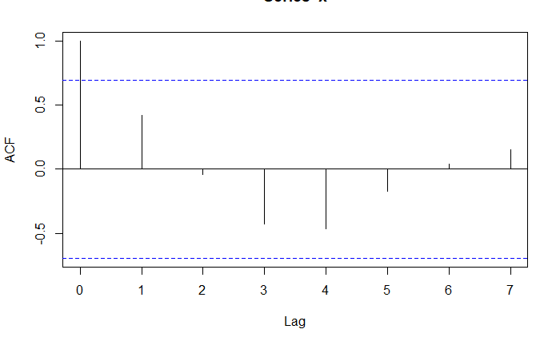

```r
# xdf = read.csv(file.choose(), header=TRUE)

# x = as.numeric((paste(xdf$Adj.Close)))

x <- c(76, 70, 66, 60, 70, 72, 76, 80)

x <- x[!is.na(x)]

n <- length(x)  # n = 8

nlag <- n - 1 # n - 1 (7)


m <- mean(x)

v <- var(x, na.rm = TRUE)

gamma0 = var(x) * (n-1) / n

aut <- acf(x, lag.max = nlag) # n - 1 (1508)
```

```r
# sum <- 0

# for (k in 1:nlag) {sum = sum + (1 - k/n) * aut$acf[k+1] * gamma0}
# vxbar = 2 * sum / n + gamma0 / n # note the multiplication of the sum by 2
# vxbar

sum_gamma_0 <- 0

for (k in 1:n) {sum_gamma_0 = sum_gamma_0 + (x[k] - m)^2}
gamma_0_manual <- sum_gamma_0 / n


sum_gamma_1 <- 0

for (k in 1:nlag) {sum_gamma_1 = sum_gamma_1 + (x[k] - m) * (x[k+1] - m)}
gamma_1_manual <- sum_gamma_1 / n



rho_1 <- gamma_1_manual / gamma_0_manual
```

Sigma^2 Hat = Gamma 0

$$\begin{equation}
\hat\gamma_0 = 34.9375
\end{equation}$$

Gamma 1

$$\begin{equation}
\hat\gamma_1 = 14.74219
\end{equation}$$

Rho Hat 0
$$\begin{equation}
\hat\rho_0 = 1
\end{equation}$$

Rho Hat 1
$$\begin{equation}
\hat\rho_1 = \hat\gamma_1 \div \hat\gamma_0 = .422
\end{equation}$$

### 1.2

The data shows a non-cyclic wandering behavior with strong correlation between values taht are near each other in time. The sample auto correlations show strong positive correlation (above 0.5 for k <= 13 ), and the periodogram and Parzen spectral estimator show peaks at zero with no indication of cyclic behavior.

#### West Texas Intermediate Crude Oil Prices

```
$autplt
 [1] 1.0000000 0.9680875 0.9160532 0.8459771 0.7724321 0.6999948 0.6419989 0.6012009 0.5720853 0.5558048
[11] 0.5455630 0.5386875 0.5239727 0.5077421 0.4902317 0.4720104 0.4483721 0.4282124 0.4124267 0.4012710
[21] 0.3920747 0.3857370 0.3761661 0.3629215 0.3418472 0.3204255

$freq
 [1] 0.008474576 0.016949153 0.025423729 0.033898305 0.042372881 0.050847458 0.059322034 0.067796610
 [9] 0.076271186 0.084745763 0.093220339 0.101694915 0.110169492 0.118644068 0.127118644 0.135593220
[17] 0.144067797 0.152542373 0.161016949 0.169491525 0.177966102 0.186440678 0.194915254 0.203389831
[25] 0.211864407 0.220338983 0.228813559 0.237288136 0.245762712 0.254237288 0.262711864 0.271186441
[33] 0.279661017 0.288135593 0.296610169 0.305084746 0.313559322 0.322033898 0.330508475 0.338983051
[41] 0.347457627 0.355932203 0.364406780 0.372881356 0.381355932 0.389830508 0.398305085 0.406779661
[49] 0.415254237 0.423728814 0.432203390 0.440677966 0.449152542 0.457627119 0.466101695 0.474576271
[57] 0.483050847 0.491525424 0.500000000

```

[output cut: 19 more lines]

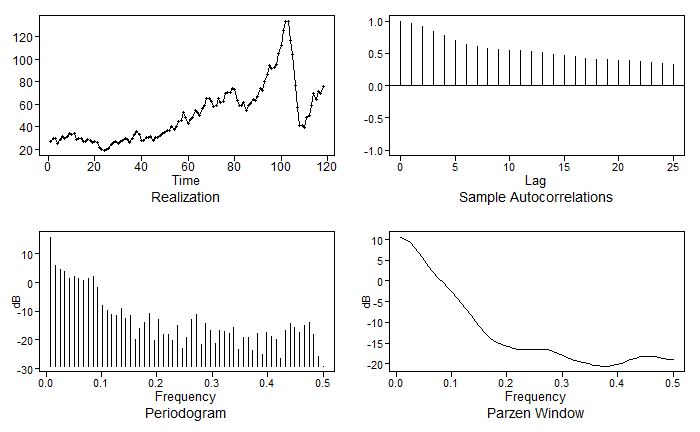

```r
data(wtcrude)
plotts.sample.wge(wtcrude)
```

#### Pennsylvania average monthly temperatures

The data show a strong cyclic behavior with a period of about 12 which makes sense (because this is monthly data). The sample auto correlations show a very slowly damping cyclic behavior with cycle length of 12 while the periodogram and Parzen spectral estimator show a strong peak at about f=1/12.

```
$autplt
 [1]  1.0000000000  0.8386381052  0.4803421817 -0.0010081916 -0.4717907055 -0.8176935421 -0.9340050360
 [8] -0.7999823229 -0.4527311287  0.0089564844  0.4659219410  0.7959391935  0.9002977221  0.7656850843
[15]  0.4360703243 -0.0098189556 -0.4511591540 -0.7618069185 -0.8701222437 -0.7482146632 -0.4297051103
[22]  0.0008229813  0.4253734168  0.7280472951  0.8317412380  0.7119144914

$freq
 [1] 0.005555556 0.011111111 0.016666667 0.022222222 0.027777778 0.033333333 0.038888889 0.044444444
 [9] 0.050000000 0.055555556 0.061111111 0.066666667 0.072222222 0.077777778 0.083333333 0.088888889
[17] 0.094444444 0.100000000 0.105555556 0.111111111 0.116666667 0.122222222 0.127777778 0.133333333
[25] 0.138888889 0.144444444 0.150000000 0.155555556 0.161111111 0.166666667 0.172222222 0.177777778
[33] 0.183333333 0.188888889 0.194444444 0.200000000 0.205555556 0.211111111 0.216666667 0.222222222
[41] 0.227777778 0.233333333 0.238888889 0.244444444 0.250000000 0.255555556 0.261111111 0.266666667
[49] 0.272222222 0.277777778 0.283333333 0.288888889 0.294444444 0.300000000 0.305555556 0.311111111
[57] 0.316666667 0.322222222 0.327777778 0.333333333 0.338888889 0.344444444 0.350000000 0.355555556
```

[output cut: 30 more lines]

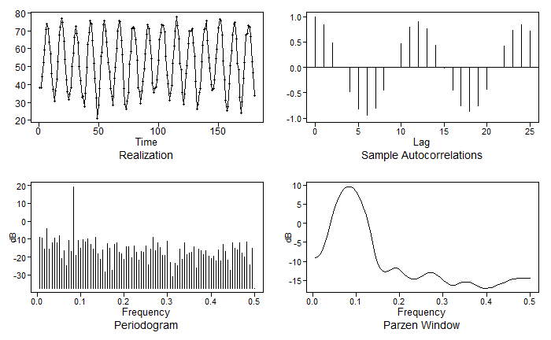

```r
plotts.sample.wge(patemp)
```

### 1.4

Realization 1

Wandering behavior which corresponds to fairly high positive auto-correlations for lags of modest length (d) and has a spectral density with a peak at zero (a).

- Auto correlations (D)
- Spectral Density (A)

Realization 2

Has very little structure (random line) which corresponds to small or zero auto-correlations (a) and a flat spectral density (d)

- Auto correlations (A)
- Spectral Density (D)

Realization 3

Pseudo-cyclic with a period of about 10 which corresponds to the auto-correlations with damped sinusoidal behavior of about 10 (b) and a peak in the spectral density of about f=0.1 (c)

- Auto correlations (B)
- Spectral Density (C)

Realization 4

- Auto correlations (C)
- Spectral Density (B)

### 1.6

The realizations shows a dominant frequency with period of about 20 along with a higher-frequency behavior. The auto correlations show the periodic behavior of associated with the period 20 (f=0.05) with some indication of a higher frequency component. These two plots provide very little evidence regarding the nature of the higher frequency behavior. The two spectral plots clearly suggest frequency behavior at both f=0.05 and f=0.35.

[figure not shown]

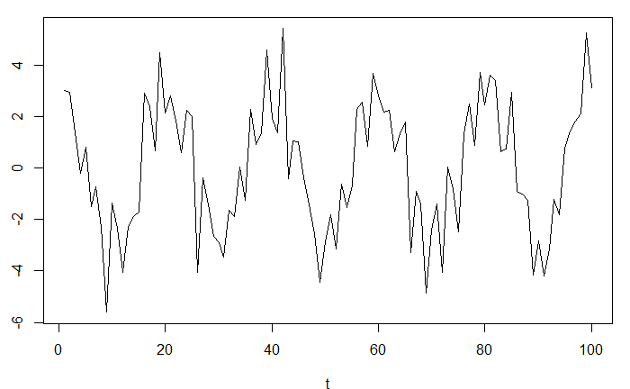

```r
x <- gen.sigplusnoise.wge(n=100, coef=c(3, 1.5), freq=c(.05, .35), psi=c(0,2))
```

```
$autplt
 [1]  1.00000000  0.60680561  0.51350724  0.51061558  0.12431402 -0.02638406 -0.16813796 -0.54127850
 [9] -0.52990888 -0.57807353 -0.76739761 -0.55307401 -0.47001647 -0.43833235 -0.06407635  0.03777649
[17]  0.08950325  0.47236462  0.48100512  0.49180648  0.64560214  0.48443461  0.43532387  0.40553356
[25]  0.06350824 -0.01745465

$freq
 [1] 0.01 0.02 0.03 0.04 0.05 0.06 0.07 0.08 0.09 0.10 0.11 0.12 0.13 0.14 0.15 0.16 0.17 0.18 0.19 0.20
[21] 0.21 0.22 0.23 0.24 0.25 0.26 0.27 0.28 0.29 0.30 0.31 0.32 0.33 0.34 0.35 0.36 0.37 0.38 0.39 0.40
[41] 0.41 0.42 0.43 0.44 0.45 0.46 0.47 0.48 0.49 0.50

$db
 [1] -21.8587440 -10.8890719 -15.8183113 -12.3941919  15.7582932  -9.4056282  -7.5375977 -11.6236320
 [9] -11.3422627  -9.9738495 -12.0060916 -22.7394261 -10.6520316 -10.5740835  -9.1025227 -19.1845976
[17]  -7.2972471 -10.5134594 -30.1408328  -9.4037860 -13.2908541  -7.8864714  -1.9943326  -9.5890951
[25]  -7.8909585 -15.4936431 -12.2218614  -0.4262813 -17.2521504 -19.0754002 -12.8631627  -6.5689449
[33] -10.5868127 -10.1613498   7.8609058 -15.5185565  -9.9369757  -7.1395899  -8.0532730  -6.7382787
[41]  -5.3376714 -14.2898099  -9.3464206 -15.3743095  -9.8051436  -4.9163692  -7.0688043  -7.8371972
[49]  -8.5962501  -8.3896961

$dbz
 [1]  3.3811880  4.8176360  6.1267277  6.9767641  7.2981443  7.0858444  6.3387946  5.0467347  3.1941121
[10]  0.7840877 -2.0822967 -5.0102455 -7.2029429 -8.2287513 -8.5577393 -8.5812027 -8.3110997 -7.7726479
[19] -7.1332793 -6.5590512 -6.1318210 -5.8685709 -5.7542098 -5.7582834 -5.8440644 -5.9711521 -6.0723184
[28] -6.0002049 -5.5301933 -4.5496030 -3.2413059 -1.9367409 -0.8899700 -0.2332647 -0.0219198 -0.2728120
[37] -0.9797796 -2.1084754 -3.5690517 -5.1678343 -6.5881773 -7.5315744 -7.9636779 -8.0828004 -8.0758603
[46] -8.0300944 -7.9778200 -7.9356931 -7.9113789 -7.9039547
```

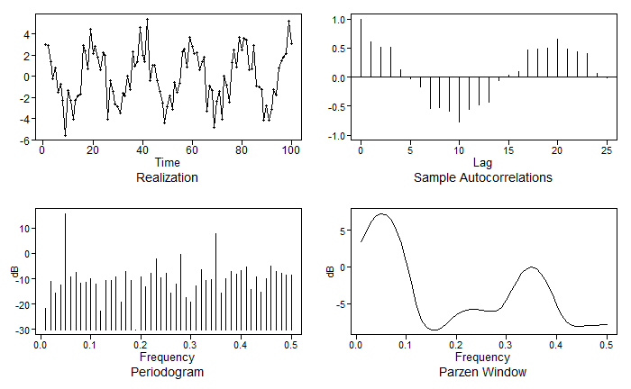

```r
plotts.sample.wge(x)
```